# wdnR: Introduction to Programming Using R

## Regression

### diagnostic plots

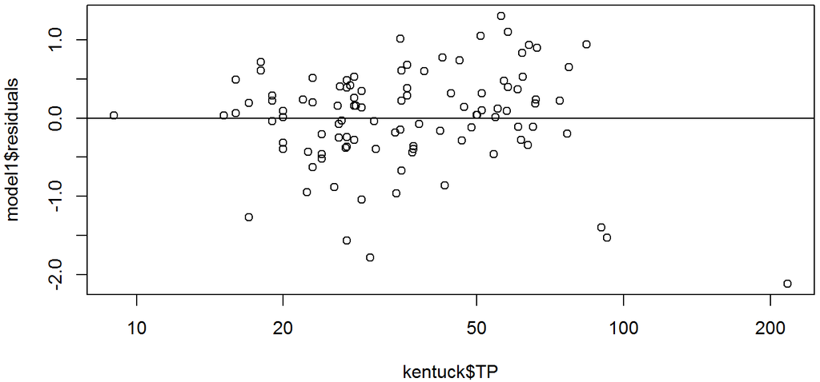

```r
par(mar=c(4,4,0.25,0.25))
plot(kentuck$TP, model1$residuals, log="x")
abline(h=0)
```

## Regression

### diagnostic plots

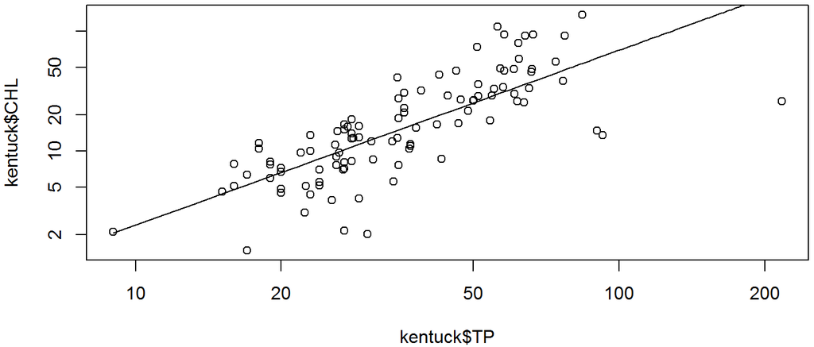

```r
par(mar=c(4,4,0.25,0.25))
plot(kentuck$TP, kentuck$CHL, log="xy")
newdata = data.frame(TP=seq(min(kentuck$TP),max(kentuck$TP),length.out=100))
newdata$CHLfit = exp(predict(model1, newdata))
lines(CHLfit~TP, newdata)
```

## t-test

`t.test` performs one and two sample unpaired or two sample paired t-tests. The only required arguments are the vector(s) of data.

**Example:** There appears to be an abrupt increase in chlorophyll in Kentuck Lake around 2011. We can use `t.test` to test whether the mean chlorophyll before 2011 is signficantly different from the mean chlorophyll after 2010.

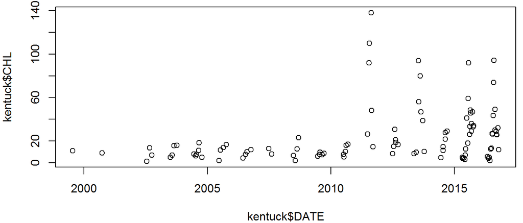

## t-test

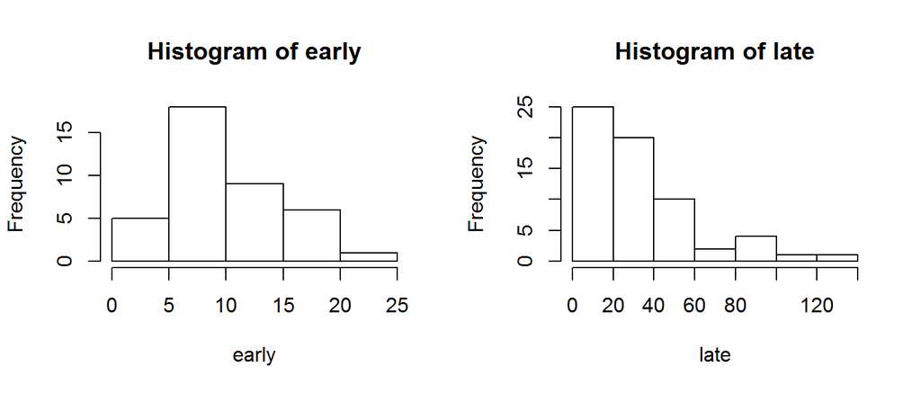

```r
early = kentuck$CHL[kentuck$DATE<as.Date("2011-01-01")]
late = kentuck$CHL[kentuck$DATE>=as.Date("2011-01-01")]
par(mfrow=c(1,2))
hist(early)
hist(late)
```

## t-test

```r
t.test(log(early),log(late))
```

```
##
##  Welch Two Sample t-test
##
## data:  log(early) and log(late)
## t = -6.1524, df = 99.992, p-value = 1.586e-08
## alternative hypothesis: true difference in means is not equal to 0
## 95 percent confidence interval:
##  -1.2654171 -0.6482979
## sample estimates:
## mean of x mean of y
##  2.139396  3.096254
```

## Exercise

Use the `lm()` function to fit a linear regression between date and log(TP) for station ID 643058 on Deerskin Lake.

Is there a significant trend in TP over time?

What are estimated TP concentrations at the beginning and end of the period of record?

## Data management

### Philosophies/Rules

Say you have a task where you need to retrieve a dataset, manipulate the data in a multi-step process, analyze the manipulated data, and return a result. One way to accomplish this task would be to use Excel. If you choose to use Excel, and most of your colleagues use Excel as well, your workflow may look something like…

## Data management

### Philosophies/Rules

1. Open a second-hand .xlsx file, try to understand what the names of the worksheets mean, and hope you select the correct data given that there are bits of fragmented tables on each worksheet.
2. Create a new .xlsx file, copy and paste your data into it, and save.
3. Create several new worksheets in your .xlsx file, each associated with an intermediate calculation.
4. Send your third-hand .xlsx file to your client/colleague, and they will repeat the above process for their task.

## Data management

### Philosophies/Rules

With your new R skills (and working with your colleagues with new R skills), you will be able to improve your workflow to look something like this:

1. Retrieve your data from the original source.
2. Write a script that contains all intermediate processing steps without needing to save any intermediate data.
3. Send your results to your client in a simple, text-based file format such as tab-delimited.

## Data management

### Philosophies/Rules

The benefits of the R-driven process is this:

1. Each step in your retrieval, manipultation, analysis, and delivery process is well-documented and repeatable.
2. You are confident you are using the correct data, you have not altered the original data in the process, and you have not created any uneccessary clutter on your hard-drive with intermediate data files.
3. Your data result will be readable 20-30 years from now even though Excel has been deprecated.

## Data management

### Philosophies/Rules

To distill the above process, here are a few general guidelines:

1. Refer to the original dataset without altering it
2. Create as few intermediate datasets as possible
3. Save your product in a simple, timeless data format

There are, of course, exceptions to the above rules, but these 3 will serve you well for most tasks.

## Data management

### Files

With respect to data management, there are two sets of functions that will serve you well. The first is the `file.*` family of functions:

```r
file.create("new_file.txt")
file.remove("old_file.txt")
file.rename("new_file.txt", "new_file2.txt")
file.copy("new_file.txt", "new_file2.txt")
```

## Data management

### Files

The second set is the `write.*` family of functions:

```r
# Write a vector of data
write(x, file="new_file.txt")
# Write character lines
writeLines(x, "new_file.txt")
# Write a text-based delimited data table
write.table(x, "new_file.txt")
write.csv(x, "new_file.txt")
```

Notice that the above files have no file path…

## Data management

### Files

If a file path is not explicitly defined, R will write to your **working directory**. You can view the working directory using the `getwd` function:

```r
getwd()
```

```
## [1] "E:/Working documents/Users/latzka/Documents/Latzka work docs/r_workshop"
```

## Data management

### Files

If you want to change the working directory, use the `setwd` function:

```r
setwd("C:/Users")
```

## Data management

### Files

A helpful shortcut is to use the tilde character (`~`) in place of your home directory:

```r
setwd("~")
getwd()
```

```
## [1] "C:/Users/latzka/Documents"
```

## Data management

### Files

Another helpful shortcut is using two dots (**`..`**) to represent one folder up:

```r
setwd("~/..")
getwd()
```

```
## [1] "C:/Users/latzka"
```

## Data management

### Files

Working with lots of files:

```r
dir.create("temp")
phrase = "All work and no play makes Jack a dull boy"
for (i in 1:500) {
  newfile = paste("temp/file", i, ".txt", sep="")
  writeLines(rep(phrase, 100), newfile)
}
setwd("temp")
newfiles = list.files()
file.remove(newfiles)
```

## Data management

### Databases

If we're going to take our data management philosophies to heart, we will need to learn how to use our databases. WDNR uses Oracle databases, and therefore we will need a special **package** to help us read data using R.

## Tangent

### Packages

Packages in R are like "plug-ins" to the basic language that extend its functionality, and they are what make R special.

Packages are community driven, and the community includes very talented individuals all the way up to giant corporations such as Oracle.

There is an R package for just about anything you can think of. All official R packages are stored in the Comprehensive R Archive Network, or **CRAN**.

## Tangent

### Packages

[interactive chart not shown]

Created using the `wordcloud2` package.

## Data management

### Databases

To connect, see **code/db_connect.html** in project folder.

## This is just the beginning…

## Advanced statistics

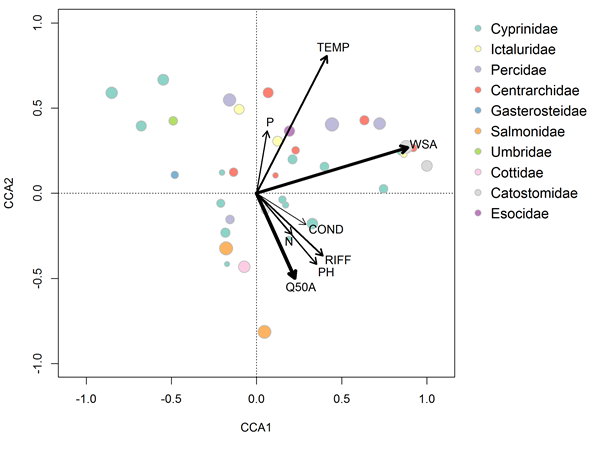

## Online apps via Shiny

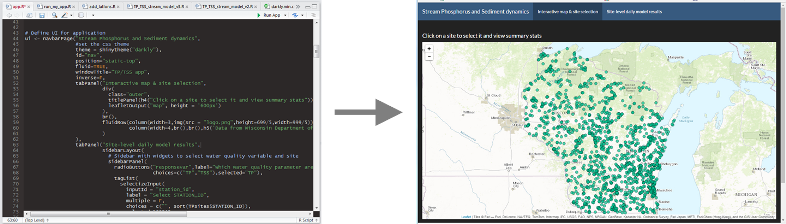

Online version of Alex's TP/TSS app

## Spatial Analysis

A **complete GIS** is available to you for free!:

- Vector (`rgeos` package) and raster (`raster` package) processing/analysis
- Robust library of coordinate systems, projections, and file type support using `rgdal` package
- Static cartography with extremely flexible base `plot` function and `ggplot2` and `ggmap` packages, and web cartography through `leaflet` including linkage with `Shiny`!
- Spatial statistics: kriging and model-fitting (`gstat` and `SSN`), point-pattern analysis (`spatstat`)

For more information, see:

http://asruesch.github.io/GeRgraphyPresentation/

## Awesome Data Visualization!

[figure not shown]

## Even the pros use it!

[figure not shown]

[figure not shown]

## 5-MINUTE BREAK

## Exercise: Tying everything together

### 45 minutes

Use the Vilas County dataset to:

Layout 2x3 plots per page as pdf

For each station:

1. Fit CHL~TP regression
2. Plot CHL vs TP data
3. Add line to plot of regression fit for the station
4. Add general CHL~TP relationship line to plot from `model` data.frame (see Kentuck Lake plots)

## Helpful references

[interactive chart not shown]

## End of Day 2, End of Workshop

```r
if(sum(YOUR_SLEEP_TIME_IN_WORKSHOP) < 1 hour)
  "Congratulations, you've graduated!"
  else
  "You have failed. Please repeat course."
```